# Homework

By 18052

2018

## Homework 1

## Question 1

Generating a series of normal random numbers.  
## Answer

```r
a=rnorm(10)
a
```

```
##  [1]  1.1722981 -1.0239012 -1.1725279  0.1402263  2.0574355  1.3969852
##  [7]  0.8465395 -1.0983968 -2.1820041 -0.4976734
```

## Question 2

Generate a matrix.  
## Answer

```r
matrix(1:6, 2, 3)
```

```
##      [,1] [,2] [,3]
## [1,]    1    3    5
## [2,]    2    4    6
```

## Question 3

Draw a scatter plot.  
## Answer

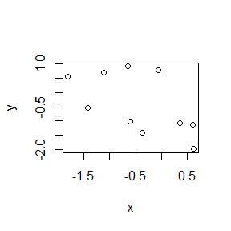

```r
x=rnorm(10)
y=rnorm(10)
plot(x,y)
```

## Homework 2

## 3.5

Problem  
A discrete random variable X has probability mass function  
x 0 1 2 3 4  
p(x) 0.1 0.2 0.2 0.2 0.3  
Use the inverse transform method to generate a random sample of size 1000 from the distribution of X. Construct a relative frequency table and compare the empirical with the theoretical probabilities. Repeat using the R sample function.

Idea  
Generate U~U(0, 1)  
If F<sub>X</sub> (x<sub>i-1</sub>) < U$\leq$ F<sub>X</sub> (x<sub>i</sub> ), then X = x<sub>i</sub> .

Result

```
## [1] 0.080 0.198 0.207 0.211 0.304
```

## 3.7:

Problem Write a function to generate a random sample of size n from the Beta(a, b) distribution by the acceptance-rejection method. Generate a random sample of size 1000 from the Beta(3,2) distribution. Graph the histogram of the sample with the theoretical Beta(3,2) density superimposed.

Result

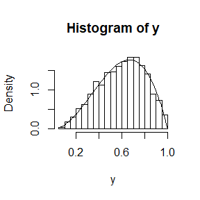

## 3.12:

Idea:  
First generate 1000 random $??'s$ which has $Gamma(r, ??)$ distribution, then generate $Y's$ which has $Exp(??'s)$ distribution.

Result

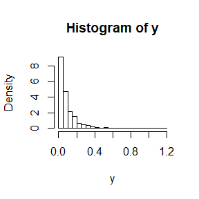

## Homework 3

## 5.4

Problem statement Write a function to compute a Monte Carlo estimate of the Beta(3, 3) cdf, and use the function to estimate F(x) for x = 0.1, 0.2, . . ., 0.9. Compare the estimates with the values returned by the pbeta function in R.

Idea If $a$ and $b$ are finite, then
$$\int_a^b h(x)dx = \int_a^b g(x)\frac1{b-a}dx=E[g(X)],$$
where $X\sim U(0,1),g(x)=(b-a)h(x).$
Use a frequency to approximation the expectation (Strong Law of Large Number):
$$\frac1m \sum_{i=1}^m g(X_i),$$
where $X_1,\ldots,X_m$ are iid copies of $X$ and $m$ is a sufficiently large integer.

Result

```
## [1] 0.008759193 0.057673376 0.165321617 0.316582912 0.498865012 0.682563764
## [7] 0.843967339 0.931756415 0.985658540
```

```
## [1] 0.00856 0.05792 0.16308 0.31744 0.50000 0.68256 0.83692 0.94208 0.99144
```

## 5.9:

Result

```
##        [,1]    [,2]    [,3]    [,4]    [,5]
## x   0.10000 0.70000 1.30000 1.90000 2.50000
## MC1 0.00124 0.05914 0.18972 0.36228 0.54172
## MC2 0.00125 0.05941 0.19046 0.36329 0.54246
## Phi 0.00125 0.05941 0.19043 0.36317 0.54217
```

```
## [1] 0.005707144
```

```
## [1] 0.001627423
```

```
## [1] 0.9186865
```

The antithetic variable approach achieved approximately 91.9% reduction in variance at x = 1.95.and $\sigma=2$.

## 5.13:

Problem statement
Find two importance functions $f_1$ and $f_2$ that are supported on $(1,\infty)$ and are ??close?? to
$$g(x) = \frac{x^2}{\sqrt{2 \pi}}e^{-x^2/2}, x > 1.$$
Which of your two importance functions should produce the smaller variance in estimating
$$\int_{1}^{\infty}\frac{x^2}{\sqrt{2 \pi}}e^{-x^2/2}dx$$
by importance sampling? Explain.
Idea:
$\theta=\int g(x)dx$ can be written as
$$\int \frac{g(x)}{f(x)}f(x)dx=E(g(X)/f(X)),$$
where $X$ has pdf/pmf $f(\cdot)$.
$f(\cdot)$ is a $f(\cdot)$ is a pdf/pmf from which random samples are easy to generate, which is called the importance function of $g(\cdot)$.
$\theta$ can be estimated with
$$\hat\theta=\frac1m\sum_{i=1}^m\frac{g(X_i)}{f(X_i)}$$
The variance of $\hat\theta$ is $var(g(X_1)/f(X_1))/m$, which has the minimal value 0 when $g(\cdot) = c f(\cdot)$ for some constant $c$.
We select $f_1=e^{-x+1}, x>1$ and $f_2=\frac{1}{2}{(x-1)}^2e^{-x+1}, x>1$.

Result

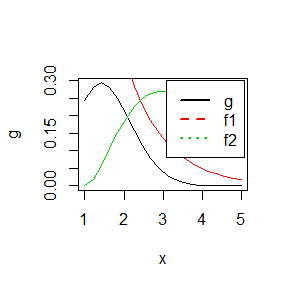

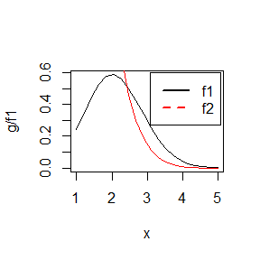

|  | f1 | f2 |
| --- | --- | --- |
| theta | 0.400 | 0.364 |
| se | 0.159 | 1.182 |

From the figure, we can see $f_1$ produces the smaller variance in estimating.

## 5.14:

Problem statement
Obtain a Monte Carlo estimate of
$$\int_{1}^{\infty}\frac{x^2}{\sqrt{2 \pi}}e^{-x^2/2}dx$$
by importance sampling.
Idea:
$\theta=\int g(x)dx$ can be written as
$$\int \frac{g(x)}{f(x)}f(x)dx=E(g(X)/f(X)),$$
where $X$ has pdf/pmf $f(\cdot)$.
$f(\cdot)$ is a $f(\cdot)$ is a pdf/pmf from which random samples are easy to generate, which is called the importance function of $g(\cdot)$.
$\theta$ can be estimated with
$$\hat\theta=\frac1m\sum_{i=1}^m\frac{g(X_i)}{f(X_i)}$$
The variance of $\hat\theta$ is $var(g(X_1)/f(X_1))/m$, which has the minimal value 0 when $g(\cdot) = c f(\cdot)$ for some constant $c$.
We select $f=e^{-x+1}, x>1$.

Result

|  | f |
| --- | --- |
| theta | 0.405 |
| se | 0.157 |

## Homework 4

## 6.9

Problem statement Let X be a non-negative random variable with $\mu=E[X]<\infty$. For a random sample $x_1,\cdots,x_n$ from the distribution of X, the Gini ratio is defined by
$$G=\frac{1}{2n^2\mu}\sum_{j=1}^{n}\sum_{i=1}^{n}|x_i-x_j|$$
The Gini ratio is applied in economics to measure inequality in income distribution . Note that G can be written in terms of the order statistics x(i) as
$$G=\frac{1}{n^2\mu}\sum_{i=1}^{n}(2i-n-1)x_{(i)}$$
If the mean is unknown, let $\hat{G}$ be the statistic G with ?? replaced by $\bar{x}$. Estimate by simulation the mean, median and deciles of $\hat{G}$ if X is standard lognormal. Repeat the procedure for the uniform distribution and Bernoulli(0.1). Also construct density histograms of the replicates in each case.

Result

```
## [1] 0.5128181 0.5107049
```

```
##       10%       20%       30%       40%       50%       60%       70%
## 0.4638178 0.4805694 0.4902141 0.5006500 0.5107049 0.5203018 0.5321593
##       80%       90%      100%
## 0.5451978 0.5664711 0.6460172
```

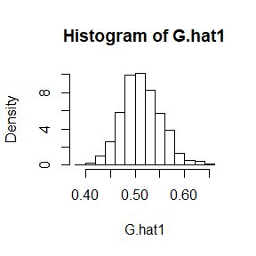

```
## [1] 0.3309144 0.3305731
```

```
##       10%       20%       30%       40%       50%       60%       70%
## 0.2993108 0.3098177 0.3193112 0.3247008 0.3305731 0.3364077 0.3429928
##       80%       90%      100%
## 0.3513647 0.3620325 0.4237325
```

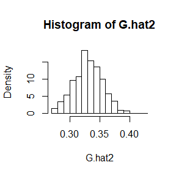

```
## [1] 0.90061 0.90000
```

```
##  10%  20%  30%  40%  50%  60%  70%  80%  90% 100%
## 0.86 0.88 0.89 0.89 0.90 0.91 0.92 0.93 0.94 0.97
```

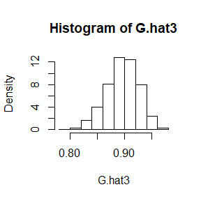

## 6.10:

Problem statement Construct an approximate 95% confidence interval for the Gini ratio $\gamma=E[G]$ if X is lognormal with unknown parameters. Assess the coverage rate of the estimation procedure with a Monte Carlo experiment.

Result

```
## [1] 0.91
```

## Homework 5

## 7.1

Problem statement  
Exercises 7.1 Compute a jackknife estimate of the bias and the standard error of the correlation statistic in Example 7.2. LSAT 576 635 558 578 666 580 555 661 651 605 653 575 545 572 594 GPA 339 330 281 303 344 307 300 343 336 313 312 274 276 288 296

Result

```
## [1] -0.006473623
```

```
## [1] 0.1425291
```

## 7.5:

Problem statement  
Refer to Exercise 7.4. Compute 95% bootstrap confidence intervals for the mean time between failures 1/?? by the standard normal, basic, percentile,and BCa methods. Compare the intervals and explain why they may differ. The 12 observations are the times in hours between failures of airconditioning equipment: 3, 5, 7, 18, 43, 85, 91, 98, 100, 130, 230, 487. Result

```
## BOOTSTRAP CONFIDENCE INTERVAL CALCULATIONS
## Based on 1024 bootstrap replicates
##
## CALL :
## boot.ci(boot.out = de, type = c("norm", "basic", "perc", "bca"))
##
## Intervals :
## Level      Normal              Basic
## 95%   ( 40.2, 178.2 )   ( 32.3, 167.5 )
##
## Level     Percentile            BCa
## 95%   ( 48.7, 183.9 )   ( 59.8, 223.9 )
## Calculations and Intervals on Original Scale
## Some BCa intervals may be unstable
```

## 7.8:

Problem statement  
Refer to Exercise 7.7. Obtain the jackknife estimates of bias and standard error of $\hat \theta$.

Result

```
## [1] 3.577503
```

```
## [1] 1.705459
```

## 7.11:

Problem statement In Example 7.18, leave-one-out (n-fold) cross validation was used to select the best fitting model. Use leave-two-out cross validation to compare the models.  
Result

```
## [1] 19.55644 17.85248 18.44188 20.45424
```

```
## [1] 60.75022 56.22732 56.67799 62.58377
```

## Homework 6

## 8.1

Problem statement Implement the two-sample Cramer-von Mises test for equal distributions as a permutation test. Apply the test to the data in Examples 8.1 and 8.2.

Result

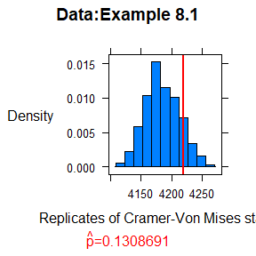

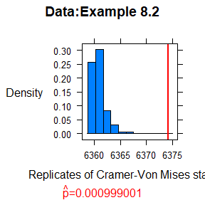

## 2:

Problem statement Design experiments for evaluating the performance of the NN, energy, and ball methods in various situations. (1)Unequal variances and equal expectations (2)Unequal variances and unequal expectations (3)Non-normal distributions: t distribution with 1 df (heavy-tailed distribution), bimodal distribution (mixture of two normal distributions) (4)Unbalanced samples (say, 1 case versus 10 controls) Result

```r
## variable definition
m <- 500 #permutation samples
p<-2 # dimension of data
n1 <- n2 <- 50 #the sample size of x and y
R<-999 #boot parameter
k<-3 #boot parameter
n <- n1 + n2
N = c(n1,n2)
# the function of NN method
Tn <- function(z, ix, sizes,k){
  n1 <- sizes[1]; n2 <- sizes[2]; n <- n1 + n2
  if(is.vector(z)) z <- data.frame(z,0);
  z <- z[ix, ];
  NN <- nn2(data=z, k=k+1)
  block1 <- NN$nn.idx[1:n1,-1]
  block2 <- NN$nn.idx[(n1+1):n,-1]
  i1 <- sum(block1 < n1 + .5)
  i2 <- sum(block2 > n1+.5)
  (i1 + i2) / (k * n)
}

eqdist.nn <- function(z,sizes,k){
  boot.obj <- boot(data=z,statistic=Tn,R=R,sim = "permutation",
                 sizes = sizes,k=k)
  ts <- c(boot.obj$t0,boot.obj$t)
  p.value <- mean(ts>=ts[1])
  list(statistic=ts[1],p.value=p.value)
}
p.values <- matrix(NA,m,3) #pֵ
```

(1)Unequal variances and equal expectations

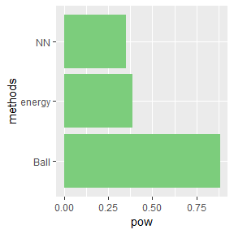

```r
##(1)Unequal variances and equal expectations
set.seed(1)
sd <- 1.5
for(i in 1:m){
  x <- matrix(rnorm(n1*p),ncol=p)
  y <- matrix(rnorm(n2*p,sd=sd),ncol=p)
  z <- rbind(x,y)
  p.values[i,1] <- eqdist.nn(z,N,k)$p.value#NN method
  p.values[i,2] <- eqdist.etest(z,sizes=N,R=R)$p.value#energy methods
  p.values[i,3] <- bd.test(x=x,y=y,R=999,seed=i*12345)$p.value# ball method
}
alpha <- 0.05;
pow <- colMeans(p.values<alpha)
power <- data.frame(methods = c('NN','energy','Ball'),pow)
ggplot(power,aes(methods,pow))+#plot
  geom_col(fill = 'palegreen3')+
  coord_flip()
```

The power of ball method is better than NN and energy methods.

(2)Unequal variances and unequal expectations

```r
##(2)Unequal variances and unequal expectations
set.seed(1)
mu <- 0.5
sd <- 1.5
for(i in 1:m){
  x <- matrix(rnorm(n1*p),ncol=p)
  y <- matrix(rnorm(n2*p,mean=mu,sd=sd),ncol=p)
  z <- rbind(x,y)
  p.values[i,1] <- eqdist.nn(z,N,k)$p.value#NN method
  p.values[i,2] <- eqdist.etest(z,sizes=N,R=R)$p.value#energy methods
  p.values[i,3] <- bd.test(x=x,y=y,R=999,seed=i*12345)$p.value# ball method
}
alpha <- 0.05;
pow <- colMeans(p.values<alpha)
pow
```

```
## [1] 0.568 0.894 0.974
```

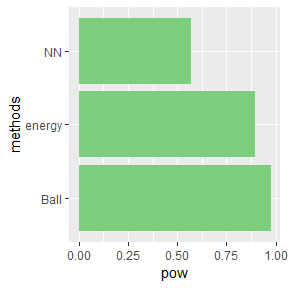

```r
power <- data.frame(methods = c('NN','energy','Ball'),pow)
ggplot(power,aes(methods,pow))+#plot
  geom_col(fill = 'palegreen3')+
  coord_flip()
```

The power of ball method is better than NN and energy methods.

(3)Non-normal distributions: t distribution with 1 df (heavy-tailed distribution), bimodal distribution (mixture of two normal distributions)

```r
##Non-normal distributions: t distribution with 1 df (heavy-tailed
##distribution), bimodal distribution (mixture of two normal
##distributions)
set.seed(1)
mu <- 0.5
sd <- 2
for(i in 1:m){
  x <- matrix(rt(n1*p,df=1),ncol=p)
  y1 = rnorm(n2*p);  y2 = rnorm(n2*p,mean=mu,sd=sd)
  w = rbinom(n, 1, .5) # 50:50 random choice
  y <- matrix(w*y1 + (1-w)*y2,ncol=p)# normal mixture
  z <- rbind(x,y)
  p.values[i,1] <- eqdist.nn(z,N,k)$p.value#NN method
  p.values[i,2] <- eqdist.etest(z,sizes=N,R=R)$p.value#energy methods
  p.values[i,3] <- bd.test(x=x,y=y,R=999,seed=i*12345)$p.value# ball method
}
alpha <- 0.05;
pow <- colMeans(p.values<alpha)
pow
```

```
## [1] 0.352 0.796 0.774
```

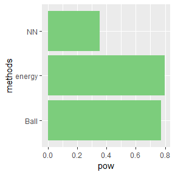

```r
power <- data.frame(methods = c('NN','energy','Ball'),pow)
ggplot(power,aes(methods,pow))+#plot
  geom_col(fill = 'palegreen3')+
  coord_flip()
```

The power of energy method is better than NN and ball methods.

(4)Unbalanced samples (say, 1 case versus 10 controls)

```r
##Unbalanced samples
set.seed(1)
mu <- 0.5
N = c(n1,n2*2)
for(i in 1:m){
  x <- matrix(rnorm(n1*p),ncol=p);
  y <- cbind(rnorm(n2*2),rnorm(n2*2,mean=mu));
  z <- rbind(x,y)
  p.values[i,1] <- eqdist.nn(z,N,k)$p.value#NN method
  p.values[i,2] <- eqdist.etest(z,sizes=N,R=R)$p.value#energy methods
  p.values[i,3] <- bd.test(x=x,y=y,R=999,seed=i*12345)$p.value# ball method
}
alpha <- 0.05;
pow <- colMeans(p.values<alpha)
pow
```

```
## [1] 0.200 0.706 0.554
```

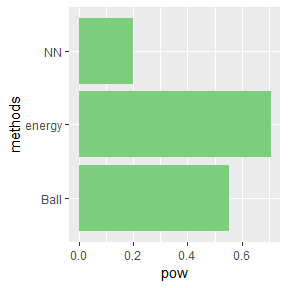

```r
power <- data.frame(methods = c('NN','energy','Ball'),pow)
ggplot(power,aes(methods,pow))+#plot
  geom_col(fill = 'palegreen3')+
  coord_flip()
```

The power of energy method is better than NN and ball methods.

## 9.3:

Problem statement
Use the Metropolis-Hastings sampler to generate random variables from a standard Cauchy distribution. Discard the first 1000 of the chain, and compare the deciles of the generated observations with the deciles of the standard Cauchy distribution (see qcauchy or qt with df=1). Recall that a Cauchy $(\theta,\eta)$ distribution has density function
$$f(x)=\frac{1}{\theta \pi (1+[(x-\eta)/\theta]^2)},\ \ -\infty < x <\infty,\theta>0$$
The standard Cauchy has the Cauchy($\theta=1,\eta=0$) density. (Note that the standard Cauchy density is equal to the Student t density with one degree of freedom.)

Result

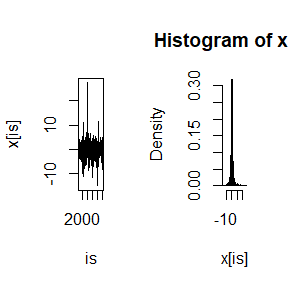

```
##      observations expectations
## 0%   -15.10789421         -Inf
## 10%   -2.80566460   -3.0776835
## 20%   -1.45826801   -1.3763819
## 30%   -0.80244110   -0.7265425
## 40%   -0.39272218   -0.3249197
## 50%   -0.09216692    0.0000000
## 60%    0.21584921    0.3249197
## 70%    0.58196503    0.7265425
## 80%    1.14386577    1.3763819
## 90%    2.42261719    3.0776835
## 100%  27.43901906          Inf
```

## Homework 7

## 11.4:

Result

```
##  [1]  1.492103  1.533549  1.562768  1.584421  1.601182  1.614523  1.625387
##  [8]  1.634409  1.642025  1.648540  1.654177  1.659098  1.663451  1.667288
## [15]  1.670736  1.673841  1.676588  1.679139  1.681461  4.795822  4.898969
## [22]  4.999990  9.999990 22.360670 31.622767
```

```
## [1]   23   24   25  100  500 1000
```

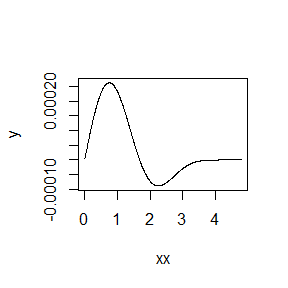

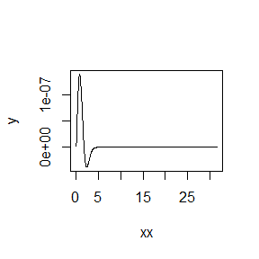

```
##        4        5        6        7        8        9       10       11
## 1.492103 1.533549 1.562768 1.584421 1.601182 1.614523 1.625387 1.634409
##       12       13       14       15       16       17       18       19
## 1.642025 1.648540 1.654177 1.659098 1.663451 1.667288 1.670736 1.673841
##       20       21       22       23       24       25      100      500
## 1.676588 1.679139 1.681461 1.683594 1.685546 1.687347 1.720601 1.729747
##     1000
## 1.730911
```

## Homework 8

## 11.6

Problem statement Write a function to compute the cdf of the Cauchy distribution, which has density
$$\frac{1}{\theta\pi(1+[(x-\eta)/\theta]^2),-\infty<x<\infty}$$
, where $\theta>0$. Compare your results to the results from the R function pcauchy. (Also see the source code in pcauchy.c.)

Result

```
## [1] 0.5
```

```
## [1] 0.5
```

```
## [1] 0.3524164
```

```
## [1] 0.3524164
```

## : A-B-O blood type problem

Problem statement  
Let the three alleles be A, B, and O.

| Genotype | AA | BB | OO | AO | BO | AB | AA |
| --- | --- | --- | --- | --- | --- | --- | --- |
| Frequency | p2 | q2 | r2 | 2pr | 2qr | 2pq | 1 |
| Count | nAA | nBB | nOO | nAO | nBO | nAB | n |

- Observed data: $n_{A\cdot}=n_{AA}+n_{AO}=28$ (A-type), $n_{B\cdot}=n_{BB}+n_{BO}=24$ (B-type), $n_{OO}=41$ (O-type), $n_{AB}=70$ (AB-type).
- Use EM algorithm to solve MLE of $p$ and $q$ (consider missing data $n_{AA}$ and $n_{BB}$).
- Record the maximum likelihood values in M-steps, are they increasing?

Result

```
##            [,1]      [,2]
##  [1,] 0.0000000 0.0000000
##  [2,] 0.2000000 0.3500000
##  [3,] 0.3162298 0.3089571
##  [4,] 0.3260961 0.3098301
##  [5,] 0.3271807 0.3103186
##  [6,] 0.3273212 0.3104097
##  [7,] 0.3273409 0.3104241
##  [8,] 0.3273438 0.3104263
##  [9,] 0.3273442 0.3104266
## [10,] 0.3273442 0.3104267
## [11,] 0.3273442 0.3104267
## [12,] 0.3273442 0.3104267
```

```
##  [1] 280.5184 283.4461 283.8643 283.9260 283.9351 283.9364 283.9366
##  [8] 283.9366 283.9366 283.9366
```

## Homework 9

## 3 p204

Problem statement Use both for loops and lapply() to fit linear models to the mtcars using the formulas stored in this list: formulas <- list( mpg ~ disp, mpg ~ I(1 / disp), mpg ~ disp + wt, mpg ~ I(1 / disp) + wt )

Result

```
## [[1]]
##
## Call:
## lm(formula = formulas[[i]], data = mtcars)
##
## Coefficients:
## (Intercept)         disp
##    29.59985     -0.04122
##
##
## [[2]]
##
## Call:
## lm(formula = formulas[[i]], data = mtcars)
##
## Coefficients:
## (Intercept)    I(1/disp)
##       10.75      1557.67
##
##
## [[3]]
##
## Call:
## lm(formula = formulas[[i]], data = mtcars)
##
## Coefficients:
## (Intercept)         disp           wt
##    34.96055     -0.01772     -3.35083
##
##
## [[4]]
##
## Call:
## lm(formula = formulas[[i]], data = mtcars)
##
## Coefficients:
## (Intercept)    I(1/disp)           wt
##      19.024     1142.560       -1.798
```

```
## [[1]]
##
## Call:
## lm(formula = x, data = mtcars)
##
## Coefficients:
## (Intercept)         disp
##    29.59985     -0.04122
##
##
## [[2]]
##
## Call:
## lm(formula = x, data = mtcars)
##
## Coefficients:
## (Intercept)    I(1/disp)
##       10.75      1557.67
##
##
## [[3]]
##
## Call:
## lm(formula = x, data = mtcars)
##
## Coefficients:
## (Intercept)         disp           wt
##    34.96055     -0.01772     -3.35083
##
##
## [[4]]
##
## Call:
## lm(formula = x, data = mtcars)
##
## Coefficients:
## (Intercept)    I(1/disp)           wt
##      19.024     1142.560       -1.798
```

## 4

Problem statement Fit the model mpg ~ disp to each of the bootstrap replicates of mtcars in the list below by using a for loop and lapply().Can you do it without an anonymous function?

Result

```
## [[1]]
##
## Call:
## lm(formula = mpg ~ disp, data = bootstraps[[i]])
##
## Coefficients:
## (Intercept)         disp
##     30.0287      -0.0434
##
##
## [[2]]
##
## Call:
## lm(formula = mpg ~ disp, data = bootstraps[[i]])
##
## Coefficients:
## (Intercept)         disp
##    29.44060     -0.03799
##
##
## [[3]]
##
## Call:
## lm(formula = mpg ~ disp, data = bootstraps[[i]])
##
## Coefficients:
## (Intercept)         disp
##    28.92155     -0.03918
##
##
## [[4]]
##
## Call:
## lm(formula = mpg ~ disp, data = bootstraps[[i]])
##
## Coefficients:
## (Intercept)         disp
##    29.10046     -0.04044
##
##
```

[output cut: 43 more lines]

```
## lm(formula = mpg ~ disp, data = bootstraps[[i]])
##
## Coefficients:
## (Intercept)         disp
##    27.47647     -0.03299
##
##
## [[10]]
##
## Call:
## lm(formula = mpg ~ disp, data = bootstraps[[i]])
##
## Coefficients:
## (Intercept)         disp
##    28.61819     -0.03719
```

```
## [[1]]
##
## Call:
## FUN(formula = ..1, data = X[[i]])
##
## Coefficients:
## (Intercept)         disp
##     30.0287      -0.0434
##
##
## [[2]]
##
## Call:
## FUN(formula = ..1, data = X[[i]])
##
## Coefficients:
## (Intercept)         disp
##    29.44060     -0.03799
##
##
## [[3]]
##
## Call:
## FUN(formula = ..1, data = X[[i]])
##
## Coefficients:
## (Intercept)         disp
##    28.92155     -0.03918
##
##
## [[4]]
##
## Call:
## FUN(formula = ..1, data = X[[i]])
##
## Coefficients:
## (Intercept)         disp
##    29.10046     -0.04044
##
##
```

[output cut: 43 more lines]

```
## FUN(formula = ..1, data = X[[i]])
##
## Coefficients:
## (Intercept)         disp
##    27.47647     -0.03299
##
##
## [[10]]
##
## Call:
## FUN(formula = ..1, data = X[[i]])
##
## Coefficients:
## (Intercept)         disp
##    28.61819     -0.03719
```

## 5

Problem statement For each model in the previous two exercises, extract R2 using the function below. rsq <- function(mod) summary(mod)$r.squared

Result:

```
## [1] 0.7183433 0.8596865 0.7809306 0.8838038
```

```
## [1] 0.7183433 0.8596865 0.7809306 0.8838038
```

```
##  [1] 0.7475099 0.7179526 0.7571433 0.6921848 0.8488426 0.7702828 0.7491175
##  [8] 0.7843995 0.6779810 0.7887093
```

```
##  [1] 0.7475099 0.7179526 0.7571433 0.6921848 0.8488426 0.7702828 0.7491175
##  [8] 0.7843995 0.6779810 0.7887093
```

## 3 p213

Problem statement The following code simulates the performance of a t-test for non-normal data. Use sapply() and an anonymous function to extract the p-value from every trial.

Result:

```
##   [1] 9.813226e-01 1.619096e-05 6.242135e-01 6.693526e-01 5.677105e-01
##   [6] 6.610740e-01 5.951636e-01 5.005347e-01 4.763110e-01 3.429965e-01
##  [11] 8.155394e-01 7.197238e-01 1.244336e-01 2.229164e-01 1.113099e-02
##  [16] 4.625765e-01 6.515865e-01 1.658793e-01 9.342672e-01 8.011934e-01
##  [21] 4.627657e-01 5.927934e-01 2.929669e-01 5.737967e-01 3.451537e-02
##  [26] 2.739138e-01 2.656151e-01 8.196695e-01 6.647355e-01 8.056529e-01
##  [31] 5.060850e-01 7.106543e-01 2.321066e-01 1.106223e-01 5.459279e-01
##  [36] 1.865470e-02 2.433776e-01 2.688851e-01 9.819256e-01 4.940184e-01
##  [41] 3.268275e-01 8.000439e-01 9.822499e-01 1.936454e-01 7.390101e-01
##  [46] 3.888930e-02 4.350424e-01 7.434339e-02 5.787441e-01 4.864951e-01
##  [51] 1.476288e-01 5.524909e-01 7.129280e-01 8.683479e-03 9.053256e-02
##  [56] 4.415463e-01 4.955063e-01 1.745328e-01 6.615399e-01 4.479199e-01
##  [61] 2.885849e-01 3.028567e-02 1.018907e-01 1.811861e-02 6.376441e-01
##  [66] 1.408742e-02 9.008128e-02 4.515933e-01 8.703291e-01 7.250768e-01
##  [71] 8.183571e-01 8.465036e-01 8.786838e-01 1.651543e-01 3.951569e-01
##  [76] 1.754280e-01 3.649865e-01 7.224226e-02 6.565152e-01 9.946559e-01
##  [81] 3.715952e-01 8.424336e-02 4.549887e-01 8.530113e-01 1.970777e-01
##  [86] 2.298117e-01 1.148832e-01 7.769502e-01 4.934348e-01 3.526049e-01
##  [91] 2.036013e-01 8.838914e-01 6.474880e-02 4.089082e-01 5.780132e-01
##  [96] 8.011408e-01 5.956061e-01 9.266689e-01 9.923205e-02 1.763972e-01
```

## 6

Problem statement Implement a combination of Map() and vapply() to create an lapply() variant that iterates in parallel over all of its inputs and stores its outputs in a vector (or a matrix). What arguments should the function take?

Result:

```
## [[1]]
## Sepal.Length  Sepal.Width Petal.Length  Petal.Width      Species
##     5.843333     3.057333     3.758000     1.199333           NA
##
## [[2]]
##        mpg        cyl       disp         hp       drat         wt
##  20.090625   6.187500 230.721875 146.687500   3.596563   3.217250
##       qsec         vs         am       gear       carb
##  17.848750   0.437500   0.406250   3.687500   2.812500
##
## [[3]]
## speed  dist
## 15.40 42.98
```

```
## [[1]]
## Sepal.Length  Sepal.Width Petal.Length  Petal.Width      Species
##     5.843333     3.057333     3.758000     1.199333           NA
##
## [[2]]
##        mpg        cyl       disp         hp       drat         wt
##  20.090625   6.187500 230.721875 146.687500   3.596563   3.217250
##       qsec         vs         am       gear       carb
##  17.848750   0.437500   0.406250   3.687500   2.812500
##
## [[3]]
## speed  dist
## 15.40 42.98
```

## Homework 10

## 4 p365

Problem statement Make a faster version of $\textbf{chisq.test()}$ that only computes the chi-square test statistic when the input is two numeric vectors with no missing values. You can try simplifying $\textbf{chisq.test()}$ or by coding from the mathematical definition.

## answer

As $\textbf{chisq.test()}$ has a long code, we try a shorter one:

```r
chisq.test2 <- function(x, y){

  # Input
  if (!is.numeric(x)) {
    stop("x must be numeric")}
  if (!is.numeric(y)) {
    stop("y must be numeric")}
  if (length(x) != length(y)) {
    stop("x and y must have the same length")}
  if (length(x) <= 1) {
    stop("length of x must be greater one")}
  if (any(c(x, y) < 0)) {
    stop("all entries of x and y must be greater or equal zero")}
  if (sum(complete.cases(x, y)) != length(x)) {
    stop("there must be no missing values in x and y")}
  if (any(is.null(c(x, y)))) {
    stop("entries of x and y must not be NULL")}

  # compute the theoretical value
  m <- rbind(x, y)#the actual value
  margin1 <- rowSums(m)
  margin2 <- colSums(m)
  n <- sum(m)
  me <- tcrossprod(margin1, margin2) / n #the theoretical value

  # Output
  STATISTIC = sum((m - me)^2 / me)
  dof <- (length(margin1) - 1) * (length(margin2) - 1)#degree of freedom
  p <- pchisq(STATISTIC, df = dof, lower.tail = FALSE)
  return(list(X_squared = STATISTIC, df = dof, `p-value` = p))
}
```

Check if $\textbf{chisq.text2()}$ returns the same results:

```r
a <- 11:15
b <- c(11,12.5,13.5,14.5,15.5)
m_test <- cbind(a,b)

identical(chisq.test(m_test),chisq.test2(a, b))
```

```
## [1] FALSE
```

The results are not same.

```r
chisq.test(m_test)
```

```
##
##  Pearson's Chi-squared test
##
## data:  m_test
## X-squared = 0.0063051, df = 4, p-value = 1
```

```r
chisq.test2(a, b)
```

```
## $X_squared
## [1] 0.006305112
##
## $df
## [1] 4
##
## $`p-value`
## [1] 0.999995
```

By observing the results, we find that there is a slight difference in p value.

Finally compare the run time:

```r
chisq.test2c <- compiler::cmpfun(chisq.test2)

microbenchmark::microbenchmark(
  chisq.test(m_test),
  chisq.test2(a,b),
  chisq.test2c(a,b)
)
```

```
## Unit: microseconds
##                expr  min   lq   mean median   uq   max neval
##  chisq.test(m_test) 75.3 84.2 90.615  85.80 89.6 224.4   100
##   chisq.test2(a, b) 20.1 24.3 27.613  25.45 28.0  67.7   100
##  chisq.test2c(a, b) 20.0 24.4 27.044  25.05 27.6  68.3   100
```

## 5 p365

Problem statement  
Can you make a faster version of for the case of an input of two integer vectors with no missing values? Can you use it to speed up your chi-square test?

## answer

```r
table2 <- function(x,y){

  x_val <- unique(x)
  y_val <- unique(y)
  mat <- matrix(0L, length(x_val), length(y_val))
  for (i in seq_along(x)) {
    mat[which(x_val == x[[i]]), which(y_val == y[[i]])] <-
      mat[which(x_val == x[[i]]),  which(y_val == y[[i]])] + 1L
  }
  dimnames <- list(x_val, y_val)
  names(dimnames) <- as.character(as.list(match.call())[-1])  # R has names for dimnames... :/
  tab <- array(mat, dim = dim(mat), dimnames = dimnames)
  class(tab) <- "table"
  tab
}
```

Then check if $\textbf{table2()}$ returns the same results:

```r
x <- c(1, 2, 3, 1, 2, 3)
y <- c(2, 3, 4, 2, 3, 4)
identical(table(x,y), table2(x,y))
```

```
## [1] TRUE
```

Finally compare the run time:

```r
microbenchmark::microbenchmark(table(x,y), table2(x,y))
```

```
## Unit: microseconds
##          expr   min     lq    mean median     uq    max neval
##   table(x, y) 204.0 293.10 417.367 325.75 398.05 1195.3   100
##  table2(x, y)  61.3  91.95 142.936 105.45 177.05  476.1   100
```